# Similar School Network

## About

Recently I came across the following post on Twitter :

> > ICYMI last week: Facebook friendships formed btw people who checked into Brazil during June https://t.co/y9h6QcSIyd [pic.twitter.com/hk0SdHR8JN](http://t.co/hk0SdHR8JN)

> > — Sean J. Taylor (@seanjtaylor) [July 24, 2014](https://twitter.com/seanjtaylor/statuses/492432734242230272)

More specifically, the map that highlights the red and blue edges to represent new friendship connections (edges) made from the World Cup. This isn’t the first time that Facebook friendships [have been overlaid onto a map](https://www.facebook.com/notes/facebook-engineering/visualizing-friendships/469716398919).

I thought it would be fun to do the same with the connections of **Similar Schools** generated by prospective Undergraduate Students. To do this, we simply need two things:

1. A dataset that represents a connection - or edge - between schools that are considered similar
2. Latitude/Longitude data for the each school

Many popular college-search sites display other institutions that are considered to be similar to the school being researched. Personally, I have found many of these lists to be approximately similar to what I get back from the Clearinghouse.

These lists aren’t perfect, but are certainly good enough for general research and certainly better than traditional student search.

## The Data

I have already crawled the data that represents the relationship between schools, but more on that in a second.

The remainder of the data is available through [IPEDS](http://nces.ed.gov/ipeds).

```r
## packages
library(plyr)
library(stringr)
library(igraph)
library(ggplot2)
library(geosphere)
```

```r
## get the lat/long data
URL = "http://nces.ed.gov/ipeds/datacenter/data/HD2013.zip"
download.file(URL, destfile = "tmp/HD2013.zip")
unzip("tmp/HD2013.zip", exdir = "tmp")
URL = "http://nces.ed.gov/ipeds/datacenter/data/HD2013_DICT.zip"
download.file(URL, destfile = "tmp/HD2013_DICT.zip")

## get the IC
URL = "http://nces.ed.gov/ipeds/datacenter/data/IC2013.zip"
download.file(URL, destfile = "tmp/IC2013.zip")
unzip("tmp/IC2013.zip", exdir = "tmp")
URL = "http://nces.ed.gov/ipeds/datacenter/data/IC2013_DICT.zip"
download.file(URL, destfile = "tmp/IC2013_DICT.zip")
```

## Data Preparation

I don’t want to keep all of the schools, so I am going to filter on the public and private 4-year schools that enroll 300 or more full-time first year students.

```r
## read the IPEDS datasets into R
hd = read.csv("tmp/hd2013.csv", stringsAsFactors=F)
colnames(hd) = tolower(colnames(hd))

## bring in the IC dataset
ic = read.csv("tmp/ic2013.csv", stringsAsFactors=F)
colnames(ic) = tolower(colnames(ic))

## not all variabels read in correctly out of the box
ic$applfeeu = as.numeric(ic$applfeeu)
ic$enrlt = as.numeric(ic$enrlt)
ic$applcn = as.numeric(ic$applcn)
ic$admssn = as.numeric(ic$admssn)

## keep the admissions data -- inner join = only if UNITID is in both files
adm = merge(hd, ic, by.x = "unitid", by.y="unitid")

## keep only domestic states
STATES = state.abb
STATES = c(STATES, "DC")
STATES = STATES[which(! STATES %in% c('AK', 'HI'))]
adm = subset(adm, stabbr %in% STATES)

## keep only 4 year public/privates
adm = subset(adm, obereg %in% 1:8)
adm = subset(adm, sector %in% 1:2)
adm = subset(adm, deggrant == 1)

## must enroll more than 300 FT FY students
## N is defined inline above in the R markdown file
adm = subset(adm, enrlt >= N)

## keep only the schools that have lat/long data
adm = subset(adm, !is.na(longitud) & !is.na(latitude))
```

This results in 1043 4-year schools in our dataset.

Now we need to filter our network dataset to only include the schools (nodes) that exist in the filtered IPEDS admissions dataset, called `adm` above. We will associate the `from` and `to` nodes (School A is similar to School B) with the geographic coordinates found in IPEDS.

```r
## bring in the network datasets (2 df's, competitors and meta)
load("~/Dropbox/Datasets/HigherEd/Cappex-April2014/parsed-data.Rdata")

## cleanup meta
meta = subset(meta, select = c(unitid, school ,rating))

## only keep schools that are in our admissions dataset
meta = subset(meta, unitid %in% adm$unitid)
edges = subset(competitors, unitid %in% adm$unitid)

## not ideal, but match the schools based on string cleaning of the school URLs
meta$url = str_join("/colleges/",
                    str_replace_all(meta$school, pattern = " ", "-"),
                    "/")

## merge the data
meta_merge = subset(meta, select = c(url, unitid))
edges = merge(edges, meta_merge, by.x = "comp", by.y = "url", all.x=T)
edges = subset(edges, select = c(unitid.x, unitid.y, rank))
names(edges) = c("from", "to", "rank")

## ensure that we have data IPEDS data on the schools in the edges dataset
edges = subset(edges, from %in% adm$unitid)
edges = subset(edges, to %in% adm$unitid)
```

Finally, merge on the lat/long data for each school.

```r
## a simple dataset for the merge
tmp_geo = subset(adm, select = c(unitid, longitud, latitude))

## merge on the lat/long for the from school
names(tmp_geo) = c("unitid", "from_long", "from_lat")
edges = merge(edges, tmp_geo, by.x="from", by.y="unitid")

## merge on the lat/long for the to school
names(tmp_geo)[2:3] = c("to_long", "to_lat")
edges = merge(edges, tmp_geo, by.x="to", by.y="unitid")
rm(tmp_geo)
```

Let’s make sure that we properly beat the data into the format we need …

```r
head(edges)
```

```
      to   from rank from_long from_lat to_long to_lat
1 100654 175342   12    -91.14    31.88  -86.57  34.78
2 100654 102234   19    -88.14    30.69  -86.57  34.78
3 100654 102368    8    -85.95    31.80  -86.57  34.78
4 100654 140960   25    -81.06    32.02  -86.57  34.78
5 100654 102377    1    -85.71    32.43  -86.57  34.78
6 100654 176044   13    -90.34    33.51  -86.57  34.78
```

## Map the data

Finally! We can start to map the data!

It may not have been obvious above, but I only kept the lower 48 states, including DC. This will make it a bit easier for mapping, although it might be cool to see how regional college competition really is.

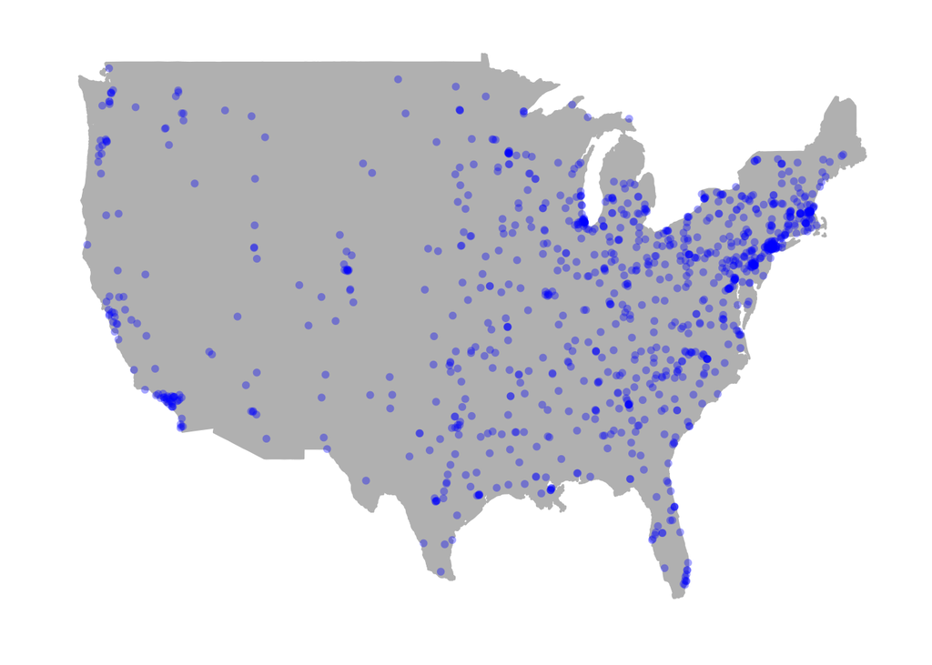

```r
## http://uchicagoconsulting.wordpress.com/tag/r-ggplot2-maps-visualization/
all_states = map_data("state")
p = ggplot() + theme(panel.background = element_blank(),
                     panel.grid = element_blank(),
                     axis.ticks = element_blank(),
                     axis.text = element_blank(),
                     axis.title = element_blank())
p = p + geom_polygon( data=all_states,
                       aes(x=long, y=lat, group = group),
                       colour="grey",
                       fill="grey")
## plot the schools
p  + geom_point(aes(adm$longitud, adm$latitude), alpha = .35, col = "blue")
```

The map above plots the location of the institutions included in our dataset. Because we have data on which schools are connected, let’s plot what that looks like on map.

Now let’s plot the connections…….

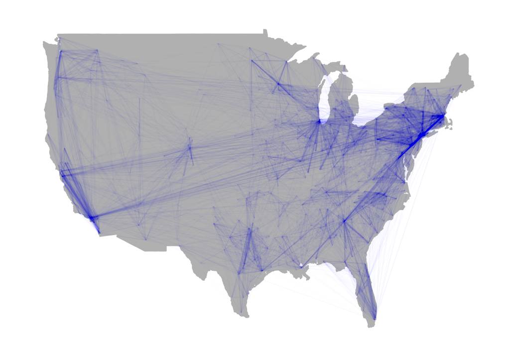

```r
## create the arcs
## http://patilv.com/USOpenCountries/
# route = gcIntermediate(edges[, c('from_long', 'from_lat')],
#                        edges[,c('to_long', 'to_lat')],
#                        50,
#                        breakAtDateLine=FALSE,
#                        addStartEnd=TRUE,
#                        sp=TRUE)
#
# # put the arcs into a data frame
# fortify.SpatialLinesDataFrame = function(model, data, ...) {
#   ldply(model@lines, fortify)
# }
# fortifiedroutes = fortify.SpatialLinesDataFrame(route)
#
#
#
# is it easier to do basic plot or take arcs for the two pairs?
#
#
## create the
p + geom_segment(aes(x=edges$from_long,
                     xend = edges$to_long,
                     y = edges$from_lat,
                     yend = edges$to_lat),
                 alpha = .0075,
                 col = "blue")
```

Let’s just keep the northeast for final detail …

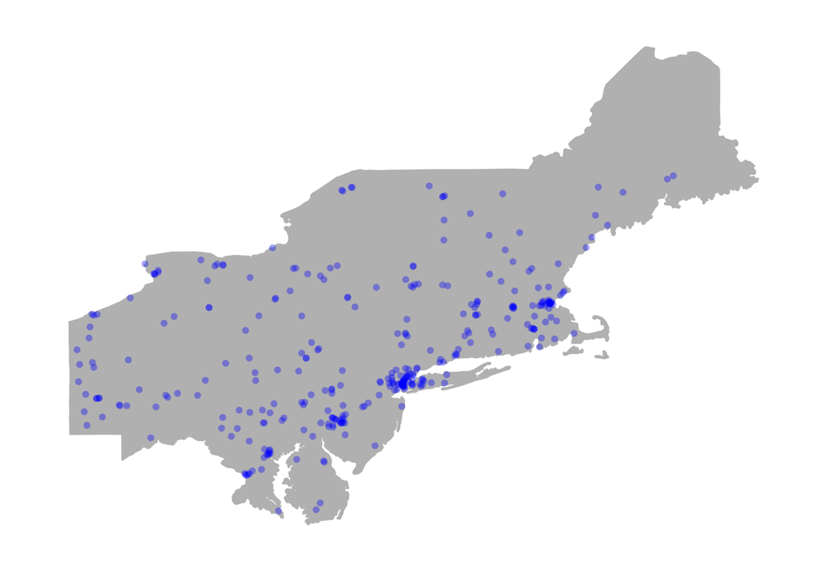

```r
## define the states
NE = c("massachusetts",
       "rhode island",
       "connecticut",
       "maine",
       "new hampshire",
       "vermont",
       "new york",
       "new jersey",
       "pennsylvania",
       "maryland",
       "delaware",
       "district of columbia")
northeast = subset(all_states, region %in% NE)

## plot the map
p = ggplot() + theme(panel.background = element_blank(),
                     panel.grid = element_blank(),
                     axis.ticks = element_blank(),
                     axis.text = element_blank(),
                     axis.title = element_blank())
p = p + geom_polygon( data=northeast,
                       aes(x=long, y=lat, group = group),
                       colour="grey",
                       fill="grey" )
#p

## plot the schools
tmp_ne = subset(adm, obereg %in% 1:2)
p1 =  p  + geom_point(aes(tmp_ne$longitud, tmp_ne$latitude) , alpha = .35, col = "blue")


## plot the lines
adm_ne = subset(adm, stabbr %in% c('CT', 'RI', 'MA', 'ME', 'NH', 'VT',
                                   'NY', 'NJ', 'PA', 'MD', 'DC', 'DE'))
edges_ne = subset(edges, to %in% adm_ne$unitid)
edges_ne = subset(edges_ne, from %in% adm_ne$unitid)
p2 = p + geom_segment(aes(x=edges_ne$from_long,
                     xend = edges_ne$to_long,
                     y = edges_ne$from_lat,
                     yend = edges_ne$to_lat),
                 alpha = .0075,
                 col = "blue")

## plot
p1
```

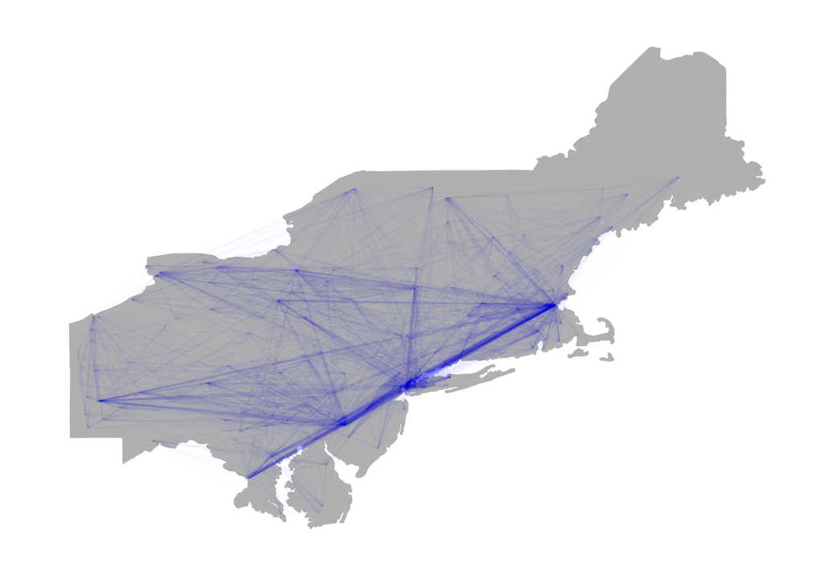

```r
p2
```

**SUMMARY NOTES FOR ABOVE**

- very regional
- on northeast, you can see how they cluster along, presumably, transporation and train lines

## Todo

- Does it make sene to do this post as Cappex and app prediction network
- do recommendation engines too
- what about other visualizations, like igraph and arcidagram package